# File S1

Jullien Flynn

2017-08-01

This is the first part of analysis including for the paper “Rates and patterns of mutation in tandem repetitive DNA in six independent lineages of Chamydomonas reinhardtii”. This file goes through the genome-wide description of tandem repeats in 6 different strains of Chlamydomonas reinhardtii.

# Look at proportion of reads containing repeats

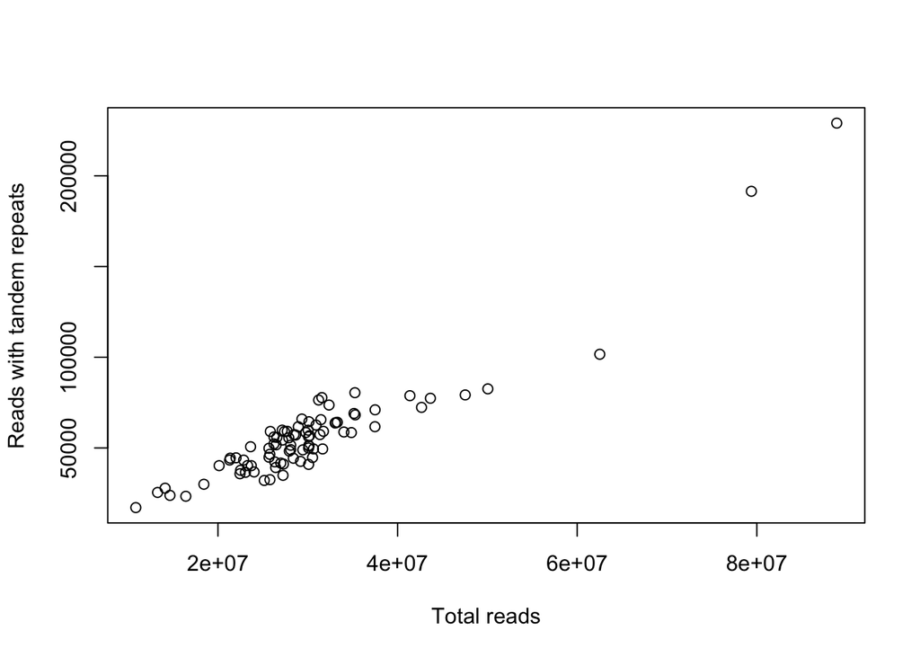

```r
reads.summary <- read.delim("~/Documents/AndyLab/Chlamy/R_Analysis/data_in/reads.summary.txt", header=FALSE)
colnames(reads.summary) <- c("File", "Repreads", "Totreads", "Proportion")
plot(x=reads.summary$Totreads, y=reads.summary$Repreads, xlab="Total reads", ylab="Reads with tandem repeats")
```

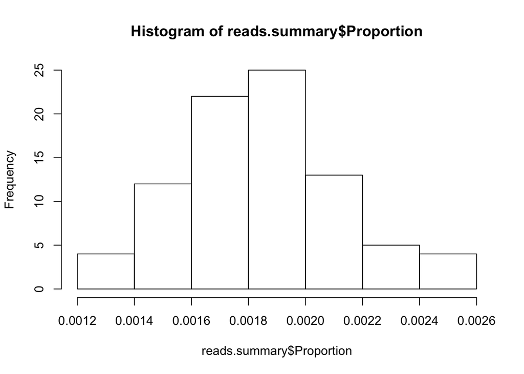

```r
hist(reads.summary$Proportion)
```

```r
summary(lm(formula = reads.summary$Repreads ~ reads.summary$Totreads))
```

```
##
## Call:
## lm(formula = reads.summary$Repreads ~ reads.summary$Totreads)
##
## Residuals:
##    Min     1Q Median     3Q    Max
## -31284  -5975    126   7195  33872
##
## Coefficients:
##                          Estimate Std. Error t value Pr(>|t|)
## (Intercept)            -1.456e+04  3.063e+03  -4.753 8.33e-06 ***
## reads.summary$Totreads  2.359e-03  9.507e-05  24.813  < 2e-16 ***
## ---
## Signif. codes:  0 '***' 0.001 '**' 0.01 '*' 0.05 '.' 0.1 ' ' 1
##
## Residual standard error: 9899 on 83 degrees of freedom
## Multiple R-squared:  0.8812, Adjusted R-squared:  0.8798
## F-statistic: 615.7 on 1 and 83 DF,  p-value: < 2.2e-16
```

```r
# p < 2.2e-16, R^2 = 0.88

# summaries:
sum(as.numeric(reads.summary$Totreads))
```

```
## [1] 2564885172
```

```r
(mean(reads.summary$Proportion))*100
```

```
## [1] 0.1847295
```

```r
sum(as.numeric(reads.summary$Repreads))
```

```
## [1] 4813300
```

# Load in and process dataset

This dataset is the counts of all kmers found by k-Seek in the 85 MA lines analyzed. Before running k-Seek, the data have been trimmed using trimmomatic to remove low quality sequences. The kmer counts have been normalized by GC content and depth.

```r
data <- read.csv('/Users/jullienflynn/Documents/AndyLab/Chlamy/R_Analysis/data_in/Chlamy_trimmed_GCcorr.compiled')
file_names <- as.vector(data$X)
rownames(data) <- file_names
data[,1] <- NULL

# match the file names to the names of the lines
Chlamy_file_info <- read.delim("~/Documents/AndyLab/Chlamy/R_Analysis/info/Chlamy_file_info.txt", header=FALSE)
Chlamy_lines <- as.vector(Chlamy_file_info[,2])
Chlamy_files <- as.vector(Chlamy_file_info[,1])
names(Chlamy_lines) <- Chlamy_files
Chlamy_lines <- as.data.frame(Chlamy_lines)

data_withnames <- merge(data, Chlamy_lines, by=0)
lines <- data_withnames[,3314]
data_withnames <- data_withnames[,-c(1,3314)]
rownames(data_withnames) <- lines
data_withnames <- as.matrix(data_withnames)

# sort the columns (kmers) by their mean abundance
kmer_means <- colMeans(data_withnames)
data_sorted <- data_withnames[,order(kmer_means, decreasing=T)]
```

## Quality check of GC correction

Some MA lines had their kmer counts corrected strongly down for GC contents ~50%. Check to see if it appears like these MA lines appear to have been over-corrected in the counts of kmers 50%. Look at the AC repeat in particular

```r
# format the data and name the rows by the MA line ID
data_withnames <- merge(data, Chlamy_lines, by=0)
ncol(data_withnames)
```

```
## [1] 3314
```

```r
lines <- data_withnames[,3314]
data_withnames <- data_withnames[,-c(1,3314)]
rownames(data_withnames) <- lines
data_withnames <- as.matrix(data_withnames)

# sort the columns (kmers) by their mean abundance
kmer_means <- colMeans(data_withnames)
data_sorted <- data_withnames[,order(kmer_means, decreasing=T)]

# Some MA lines were strongly corrected near 50% GC - check if this seems reasonable by the corrected copy number
data_sorted["CC-2937_MA1", 1:5]
```

```
##       AC      AGC AAAACCCT        C   AGGCGG
##    44678     6549     1980     6801      313
```

```r
data_sorted["CC-2937_MA2", 1:5]
```

```
##       AC      AGC AAAACCCT        C   AGGCGG
##    43609     7169     2118     3165      239
```

# Get the abundant kmers

## Abundant kmers within each ancestor

```r
# function that takes in a matrix of copy numbers and returns the indexes of kmers that have a mean copy number across all MA lines of at least 100
get_common_kmers <- function (kmer_matrix) {
  common.kmer.indexes <- c()
  for (i in 1:ncol(kmer_matrix)) {
    if (mean(kmer_matrix[,i])>=100) {
      common.kmer.indexes <- c(common.kmer.indexes, i)
    }
  }
  names(common.kmer.indexes) <- colnames(kmer_matrix)[common.kmer.indexes]
  return (common.kmer.indexes)
}

# make a new matrix for each ancestral group
data_1373 <- data_sorted[which (substr(rownames(data_sorted), start = 1, stop = 7) == "CC-1373"),  ]
data_1952 <- data_sorted[which (substr(rownames(data_sorted), start = 1, stop = 7) == "CC-1952"),  ]
data_2342 <- data_sorted[which (substr(rownames(data_sorted), start = 1, stop = 7) == "CC-2342"),  ]
data_2344 <- data_sorted[which (substr(rownames(data_sorted), start = 1, stop = 7) == "CC-2344"),  ]
data_2931 <- data_sorted[which (substr(rownames(data_sorted), start = 1, stop = 7) == "CC-2931"),  ]
data_2937 <- data_sorted[which (substr(rownames(data_sorted), start = 1, stop = 7) == "CC-2937"),  ]

# get the common kmer indexes for each ancestral group, and how many each has
common.kmer.indexes_1373 <- get_common_kmers(data_1373)
length(common.kmer.indexes_1373) # 28
```

```
## [1] 28
```

```r
common.kmer.indexes_1952 <- get_common_kmers(data_1952)
length(common.kmer.indexes_1952) # 31
```

```
## [1] 31
```

```r
common.kmer.indexes_2342 <- get_common_kmers(data_2342)
length(common.kmer.indexes_2342) # 31
```

```
## [1] 31
```

```r
common.kmer.indexes_2344 <- get_common_kmers(data_2344)
length(common.kmer.indexes_2344) # 26
```

```
## [1] 26
```

```r
common.kmer.indexes_2931 <- get_common_kmers(data_2931)
length(common.kmer.indexes_2931) # 29
```

```
## [1] 29
```

```r
common.kmer.indexes_2937 <- get_common_kmers(data_2937)
length(common.kmer.indexes_2937) # 29
```

```
## [1] 29
```

## Get the kmers that have at least 1000 copies

```r
get_1000_kmers <- function (kmer_matrix) {
  common.kmer.indexes <- c()
  for (i in 1:ncol(kmer_matrix)) {
    if (mean(kmer_matrix[,i])>=1000) {
      common.kmer.indexes <- c(common.kmer.indexes, i)
    }
  }
  names(common.kmer.indexes) <- colnames(kmer_matrix)[common.kmer.indexes]
  return (common.kmer.indexes)
}
kmer1000.indexes_1373 <- get_1000_kmers(data_1373)
kmer1000.indexes_1373 # length 4
```

```
##         AC        AGC   AAAACCCT AAATAACAAT
##          1          2          3         22
```

```r
kmer1000.indexes_1952 <- get_1000_kmers(data_1952)
kmer1000.indexes_1952 # length 5
```

```
##              AC             AGC        AAAACCCT               C
##               1               2               3               4
## AAATTTATATACTCC
##              14
```

```r
kmer1000.indexes_2342 <- get_1000_kmers(data_2342)
kmer1000.indexes_2342 # length 6
```

```
##             AC            AGC       AAAACCCT              C         AGGCGG
##              1              2              3              4              5
## AAATAGCAGTATAT
##              8
```

```r
kmer1000.indexes_2344 <- get_1000_kmers(data_2344)
kmer1000.indexes_2344 # length 3
```

```
##       AC      AGC AAAACCCT
##        1        2        3
```

```r
kmer1000.indexes_2931 <- get_1000_kmers(data_2931)
kmer1000.indexes_2931 # length 7
```

```
##             AC            AGC       AAAACCCT              C         AGGCGG
##              1              2              3              4              5
##            AAT AAATAGCAGTATAT
##              6              8
```

```r
kmer1000.indexes_2937 <- get_1000_kmers(data_2937)
kmer1000.indexes_2937 # length 5
```

```
##       AC      AGC AAAACCCT        C      AAT
##        1        2        3        4        6
```

## Get the AC repeat means

AC is the most abundant repeat in all ancestors.

```r
mean (data_1373[,which(colnames(data_1373) == "AC")])
```

```
## [1] 26421.62
```

```r
mean (data_1952[,which(colnames(data_1952) == "AC")])
```

```
## [1] 28276.29
```

```r
mean (data_2342[,which(colnames(data_2342) == "AC")])
```

```
## [1] 35059.86
```

```r
mean (data_2344[,which(colnames(data_2344) == "AC")])
```

```
## [1] 35291.07
```

```r
mean (data_2931[,which(colnames(data_2931) == "AC")])
```

```
## [1] 31574.71
```

```r
mean (data_2937[,which(colnames(data_2937) == "AC")])
```

```
## [1] 26928.93
```

## Get the union and intersection of the common kmers

```r
shared.common.kmers <- Reduce(intersect, list
       (names(common.kmer.indexes_1373), names(common.kmer.indexes_1952),
       names(common.kmer.indexes_2342), names(common.kmer.indexes_2344),
       names(common.kmer.indexes_2931), names(common.kmer.indexes_2937)
       ))
shared.common.kmers
```

```
##  [1] "AC"       "AGC"      "AAAACCCT" "C"        "AGGCGG"   "AAT"
##  [7] "AGGC"     "ACGC"     "AAC"      "ACACGC"   "AGGCGC"   "ACCGGC"
## [13] "CCG"      "ACC"      "AGGGC"    "ACCCGC"   "AGCGGC"   "AGG"
```

```r
length(shared.common.kmers)
```

```
## [1] 18
```

```r
#write(shared.common.kmers, file="/Users/jullienflynn/Documents/AndyLab/Chlamy/R_Analysis/data_in/chlamy_shared.common.kmers.txt", sep="\n")

common.kmer.union <- Reduce(union, list
       (names(common.kmer.indexes_1373), names(common.kmer.indexes_1952),
       names(common.kmer.indexes_2342), names(common.kmer.indexes_2344),
       names(common.kmer.indexes_2931), names(common.kmer.indexes_2937)
       ))
common.kmer.union
```

```
##  [1] "AC"                   "AGC"                  "AAAACCCT"
##  [4] "C"                    "AGGCGG"               "AAT"
##  [7] "AGGC"                 "ACGC"                 "AAC"
## [10] "ACACGC"               "AAATACCTTACGGGAATAT"  "AGGCGC"
## [13] "ACCGGC"               "CCG"                  "ACC"
## [16] "AGGGC"                "ACCCGC"               "AAATAACAAT"
## [19] "AGCGGC"               "AAAGT"                "AGG"
## [22] "ACAGGG"               "ATC"                  "ACGCCC"
## [25] "AAATACTTACGGGAATAT"   "AGCGCC"               "AGCGGG"
## [28] "ACCCGG"               "AAATTTATATACTCC"      "ACAGGC"
## [31] "ACCAGC"               "AAAGAAGTATATAAAT"     "AAAATATATAAATATAGCT"
## [34] "AGCCGG"               "AGCCGC"               "AATAGATAATAT"
## [37] "AAATAGCAGTATAT"       "AAAAAGGTAAATGTATTTAT" "ACGCC"
## [40] "AGGGCC"               "AGGGGC"               "AGAGGC"
## [43] "AAAATAAAGTGT"         "ACTGGGC"              "AAACAC"
## [46] "AAAC"
```

```r
length(common.kmer.union)
```

```
## [1] 46
```

```r
# get the indexes of the common kmers
common.kmer.union.indexes <- Reduce(union, list
       (common.kmer.indexes_1373, common.kmer.indexes_1952,
       common.kmer.indexes_2342, common.kmer.indexes_2344,
       common.kmer.indexes_2931, common.kmer.indexes_2937
       ))
```

# PCA

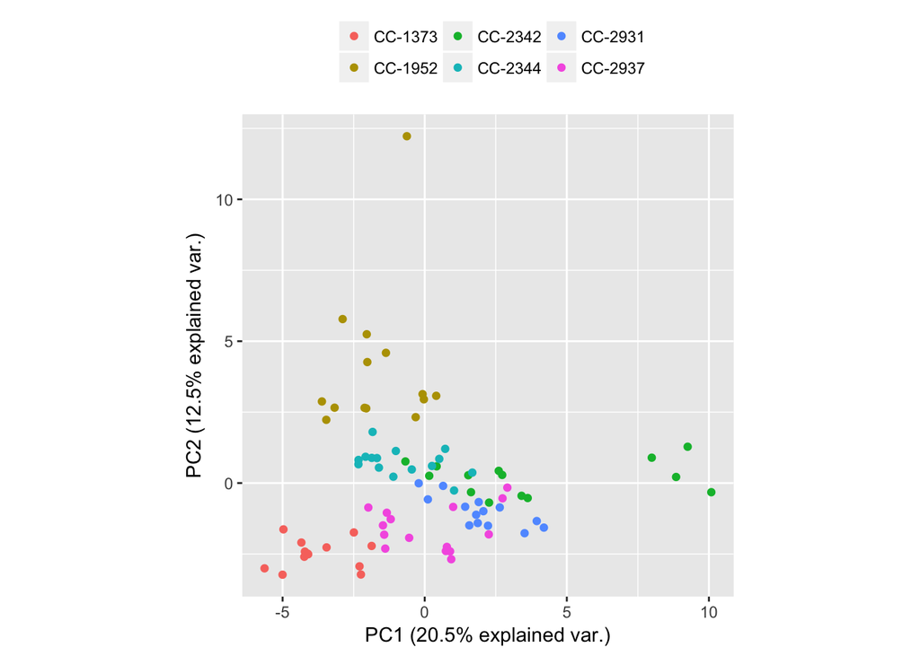

```r
get_ancestor <- function(row_number) {
  Anc <- substr(rownames(data_sorted)[row_number], start = 1, stop = 7)
  return (Anc)
}

category <- c()
for (i in 1:nrow(data_sorted)) {
  category <- c(category, get_ancestor(i))
}
pca.data <- prcomp(data_sorted[, common.kmer.union.indexes], scale.=T)

# using the 46 union kmers
g <- ggbiplot(pca.data, obs.scale = 1, var.scale = 1, groups = category, var.axes = F)
g <- g + scale_color_discrete(name='')
g <- g + theme(legend.direction='horizontal', legend.position='top')
print(g)
```

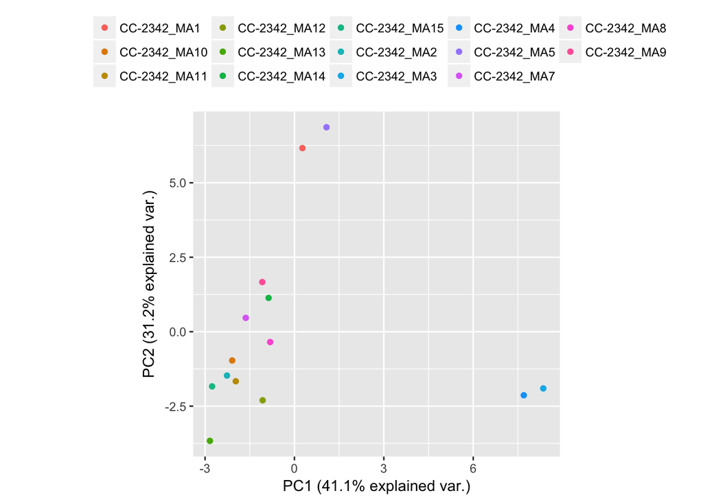

```r
# what are these 4 samples that are separated from the rest of their group?

MA_names <- rownames(data_2342)
pca.data_2342 <- prcomp(data_2342[, common.kmer.indexes_2342], scale.=T)

g <- ggbiplot(pca.data_2342, obs.scale = 1, var.scale = 1, groups = MA_names, var.axes = F)
g <- g + scale_color_discrete(name='')
g <- g + theme(legend.direction='horizontal', legend.position='top')
print(g)
```

```r
data_2342[,1:10]
```

```
##                 AC  AGC AAAACCCT     C AGGCGG  AAT AGGC AAATAGCAGTATAT
## CC-2342_MA2  27495 6542     1544   457    945  886  463            373
## CC-2342_MA3  31747 5932     1861  2459   2424   62 2034           1294
## CC-2342_MA4  28322 5846     2018  2864   2361  228 2006           6268
## CC-2342_MA5  51735 6784     1324 13656   1802  949 1058            523
## CC-2342_MA7  42453 6692     1107   859    933 1987  595            872
## CC-2342_MA8  35689 6193     1285   625    917 1528  559           1340
## CC-2342_MA9  47907 6102     1934  2357   1454  854  598            720
## CC-2342_MA10 23678 6242     1960   824   1294 2125  410           3790
## CC-2342_MA11 26074 6215     2054   649   1322 1613  365           2992
## CC-2342_MA12 33869 5582     1390     0    916  226  440           4167
## CC-2342_MA13 19013 6467     1928   326    827  650  376           2035
## CC-2342_MA15 28926 6460     1361    82    989  627  406           1293
## CC-2342_MA1  54612 6729     1359 12161   1498  699  885            434
## CC-2342_MA14 39318 6080     1325  1853   1256  311  719            858
##              ACGC  AAC
## CC-2342_MA2   320  343
## CC-2342_MA3  1745  382
## CC-2342_MA4  1148  939
## CC-2342_MA5   607  987
## CC-2342_MA7   484  367
## CC-2342_MA8   482  332
## CC-2342_MA9   595  342
## CC-2342_MA10  345 1078
## CC-2342_MA11  320 1226
## CC-2342_MA12  313  266
## CC-2342_MA13  231  284
## CC-2342_MA15  319  332
## CC-2342_MA1   561  943
## CC-2342_MA14  616  351
```

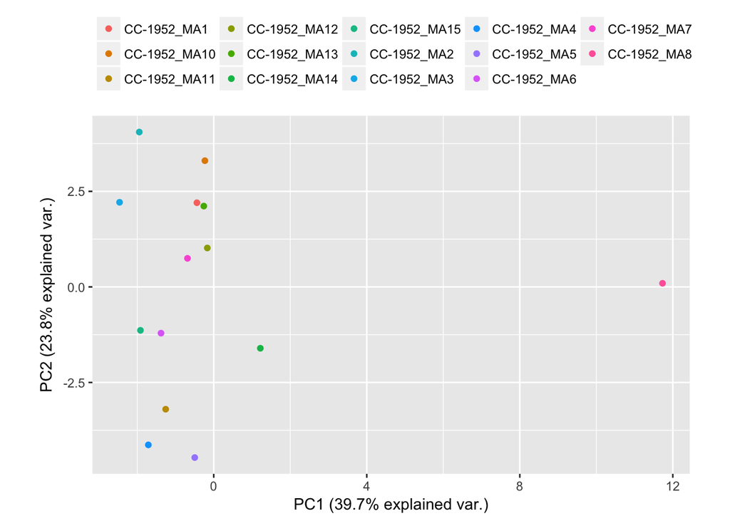

```r
# likely MA1 and MA5 are outliters because of poly-C repeat, MA3 and MA4 because of AGGC repeat

# what about the 1952 sample?
MA_names <- rownames(data_1952)
pca.data_1952 <- prcomp(data_1952[, common.kmer.indexes_1952], scale.=T)

g <- ggbiplot(pca.data_1952, obs.scale = 1, var.scale = 1, groups = MA_names, var.axes = F)
g <- g + scale_color_discrete(name='')
g <- g + theme(legend.direction='horizontal', legend.position='top')
print(g)
```

```r
data_1952[,1:10]
```

```
##                 AC  AGC AAAACCCT    C AGGCGG  AAT AGGC AAATAGCAGTATAT ACGC
## CC-1952_MA1  35987 6546     1856 2276    654  642  677              1  763
## CC-1952_MA2  34929 7259     1828  156    595 1045  763              0  680
## CC-1952_MA3  37201 7443     1877  216    538  611  742              0  660
## CC-1952_MA4  25561 6583     3050   42    310  229  454              0  267
## CC-1952_MA5  20052 6478     2340  133    347  233  545              0  332
## CC-1952_MA6  27441 6877     1893  240    492  961  546              0  397
## CC-1952_MA7  25441 6688     2267  431    597 1211  636              0  500
## CC-1952_MA8  14749 6294      993 7711    474 1848  923              0  842
## CC-1952_MA10 38330 6769     3192   79    576  727  720              0  659
## CC-1952_MA11 20893 6281     2232  243    388  636  535              0  372
## CC-1952_MA12 29318 6620     1953  124    444 1545  643              2  544
## CC-1952_MA13 27513 6414     1947 3195    542   36  511              1  577
## CC-1952_MA14 25832 6690     1945  132    386 1159  505              0  457
## CC-1952_MA15 32621 6671     1975  208    388  603  560              0  439
##              AAC
## CC-1952_MA1  290
## CC-1952_MA2  257
## CC-1952_MA3  241
## CC-1952_MA4  317
## CC-1952_MA5  260
## CC-1952_MA6  297
## CC-1952_MA7  256
## CC-1952_MA8  179
## CC-1952_MA10 836
## CC-1952_MA11 302
## CC-1952_MA12 345
## CC-1952_MA13 326
## CC-1952_MA14 311
## CC-1952_MA15 281
```